# ベルヌーイ分布と二項分布

**ベルヌーイ分布 (Bernoulli distribution)** は、二値確率変数 $x \in \{ 0,1 \}$ をとる離散分布です。

- $x=1$ となる確率を $\pi \quad (0 \leq \pi \leq 1)$
- $x=0$ となる確率を $1-\pi$

とします。ベルヌーイ分布は、 $\pi$ をパラメータとして、

$${\rm Bernoulli} (x|\pi) \equiv \pi^x (1-\pi)^{1-x} \quad (x \in \{ 0,1 \})$$

で定義されます。ベルヌーイ分布に従う $n$ 回の独立した試行を考えます。

- $x_i \in \{ 0,1 \}$ により、$i$ 回目の試行を、
- $n_0$ で0が出た回数を、
- $n_1$ で1が出た回数を、

表すこととします。$\pi$ が与えられたもとでの $\boldsymbol{x} = \{ x_1,x_2,...,x_n \}$ の確率は、

$$p(\boldsymbol{x} | \pi) = \prod^n_{i=1} p(x_i|\pi) = \pi^{n_1} (1-\pi)^{n_0}$$

と計算できます。

**二項分布 (binomial distribution)** は $\pi$ と $n$ をパラメータとして、

$${\rm Bi} (n_1 | \pi, n) \equiv \frac{n!}{{n_1}!(n-n_1)!} \pi^{n_1} (1-\pi)^{n-n_1}$$

で定義され、各試行における値ではなく、 $n$ 回の試行における1の出現回数に興味がある場合に、 $n_1$ を $\pi$ と $n$ をパラメータとして表現します。

R で二項分布の確率密度を表現する関数`dbinom`を使って、二項分布のグラフを描きます。表と裏の出る確率が同じ0.5であるコインを投げて、表(裏)の出る回数が1~50になる確率をプロットします。

10回～50回投げたときのプロットの変化を重ね描きします。

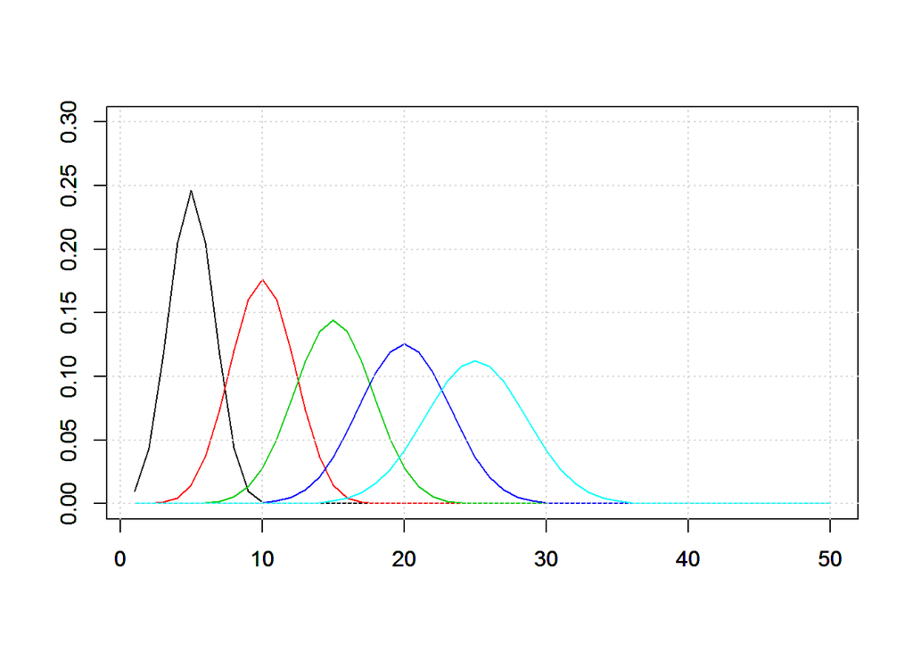

```r
par(ann=F)
plot(1:50,dbinom(1:50, 10, p=0.5),type="l",ylim=c(0,0.3),col=1)
par(new=T)
plot(1:50,dbinom(1:50, 20, p=0.5),type="l",ylim=c(0,0.3),col=2)
par(new=T)
plot(1:50,dbinom(1:50, 30, p=0.5),type="l",ylim=c(0,0.3),col=3)
par(new=T)
plot(1:50,dbinom(1:50, 40, p=0.5),type="l",ylim=c(0,0.3),col=4)
par(new=T)
plot(1:50,dbinom(1:50, 50, p=0.5),type="l",ylim=c(0,0.3),col=5)
grid()
```